# Bayesian SIR Model

Luis Martinez Lomeli

The Susceptible-Infectious-Recovered model is one of the most well known models in epidemiology and mathematical biology. It describes the three different stages or compartments that individuals in a population can go through when they are exposed to an infectious agent.

The classic formulation of the SIR model is based on a differential equations model written as

$\frac{dS}{dt}=-\beta S I^\alpha$

$\frac{dI}{dt}=\beta S I^\alpha - \gamma I$

$\frac{dR}{dt}=\gamma I$

$S(0)=S_0, I(0)=I_0, R(0)=R_0$

where $alpha$, $\beta$ and $\gamma$ represent the mixing, infection and recovery rates respectively. Note that the individuals in the Recovered compartment can also be considered to be Removed as in multiple places of the literature.

```r
rm(list=ls())

library(ggplot2)
library(rstan)
rstan_options(auto_write = TRUE)
options(mc.cores = parallel::detectCores())
require(plyr)
library(reshape2)
library(deSolve)
library(utils)

RUN_STAN = FALSE  #If FALSE, then will load previously simulated samples
```

We will use a real dataset known as the `Eyam` dataset. This dataset describe the spread of the bubonic plague in the remote village of Eyam in England from June 18th to October 20th, 1666. An intresting article about this epidemic can be found [here](https://www.bbc.com/news/uk-england-35064071)

```r
getwd()
```

```
## [1] "C:/Users/luis_/GitHub/BayesianMechanisticModeling"
```

```r
download.file(url = "https://github.com/msuchard/MultiBD/raw/master/data/Eyam.rda",
              destfile = "data/Eyam.rda")
load('data/Eyam.rda')
print(Eyam)
```

```
##   time   S  I   R
## 1  0.0 254  7   0
## 2  0.5 235 14  12
## 3  1.0 201 22  38
## 4  1.5 153 29  79
## 5  2.0 121 20 120
## 6  2.5 110  8 143
## 7  3.0  97  8 156
## 8  4.0  83  0 178
```

```r
TOT_POP_EYAM = sum(Eyam[1,2:4])

df_Eyam = melt(data = Eyam, id.vars='time', variable.name = "Pop")
head(df_Eyam)
```

|  | time | Pop | value |
| --- | --- | --- | --- |
| 1 | 0.0 | S | 254 |
| 2 | 0.5 | S | 235 |
| 3 | 1.0 | S | 201 |
| 4 | 1.5 | S | 153 |
| 5 | 2.0 | S | 121 |
| 6 | 2.5 | S | 110 |

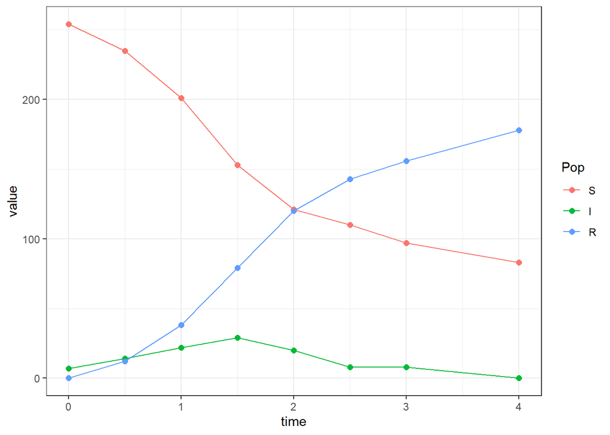

```r
ggplot() +
  geom_point(data=df_Eyam,
           aes(x=time, y=value, group=Pop, colour=Pop) , size=2)  +
  geom_line(data=df_Eyam, aes(x=time, y=value, group=Pop, colour=Pop)) +
  theme_bw() -> lm_plot_base
print(lm_plot_base)
```

#SIR model

The first step in our analysis is to forward run the model with fixed parameters and initial conditions.

## Foward run with fixed parameters

```r
# We choose population sizes and parameters values arbitrarily for illustration purposes

state = c(S = 9999, I = 1, R = 0)
TOT_POP = sum(state)
parms = c(alpha = 1, beta = 5/TOT_POP, gamma = 1)

SIR_ODE = function(t, state, parms) {
  with(as.list(c(state, parms)),{

  # rates of change
  dS = - beta*S*(I^alpha)
  dI = beta*S*(I^alpha) - gamma*I
  dR = gamma*I

  # return the rates of change
  list(c(dS, dI, dR))
})
}

#Solution times
times <- seq(0, 10, by = 0.25)

SIR_sol = data.frame(ode(y = state, times = times, func = SIR_ODE, parms = parms))
head(SIR_sol)
```

|  | time | S | I | R |
| --- | --- | --- | --- | --- |
| 1 | 0.00 | 9999.000 | 1.000000 | 0.0000000 |
| 2 | 0.25 | 9996.853 | 2.717645 | 0.4295226 |
| 3 | 0.50 | 9991.021 | 7.382179 | 1.5965406 |
| 4 | 0.75 | 9975.208 | 20.027769 | 4.7646263 |
| 5 | 1.00 | 9932.503 | 54.151502 | 13.3450711 |
| 6 | 1.25 | 9818.469 | 145.090825 | 36.4396900 |

```r
df_ode_sol = melt(data = SIR_sol, id.vars='time', variable.name = "Pop")
head(df_ode_sol)
```

|  | time | Pop | value |
| --- | --- | --- | --- |
| 1 | 0.00 | S | 9999.000 |
| 2 | 0.25 | S | 9996.853 |
| 3 | 0.50 | S | 9991.021 |
| 4 | 0.75 | S | 9975.208 |
| 5 | 1.00 | S | 9932.503 |
| 6 | 1.25 | S | 9818.469 |

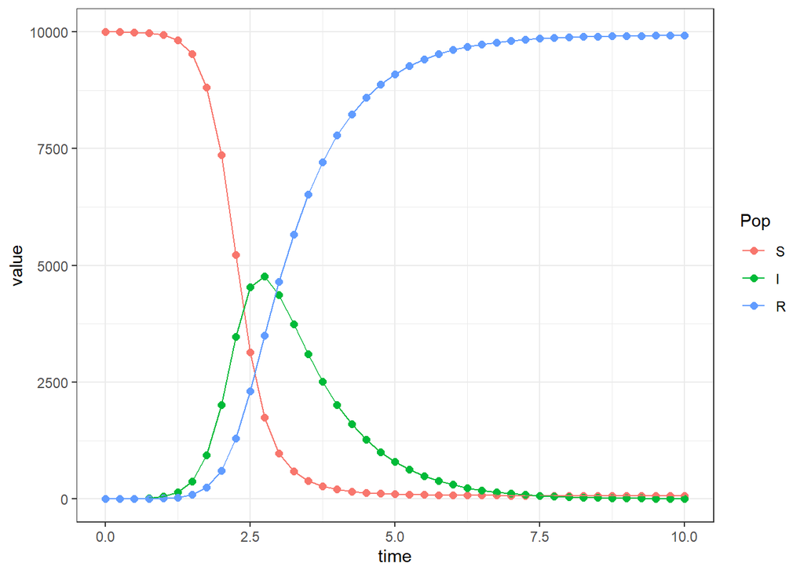

```r
ggplot() +
  geom_point(data=df_ode_sol,
           aes(x=time, y=value, group=Pop, colour=Pop) , size=2)  +

  geom_line(data=df_ode_sol, aes(x=time, y=value, group=Pop, colour=Pop)) +
  theme_bw()
```

# Fitting the SIR model in STAN

Now, we fit the model where we especify all the elements to pass to STAN.

```r
stan_data = list(TOT_POP = TOT_POP_EYAM, TOT_SUBPOP = 3, t0 = Eyam$time[1],
                ts = Eyam$time[-1], N_ts = length(Eyam$time[-1]),
                y_init = as.numeric(Eyam[1, c('S', 'I', 'R')]),
                y_obs = Eyam[-1, c('S', 'I', 'R')], eps = rep(1e-5,3)
                )

cat(readLines('SIR_w-alpha.stan'), sep = '\n')
```

```
## functions {
##    real[] SIR_ODE(real t, real[] y, real[] theta, real[] x_r, int[] x_i) {
##      real alpha = theta[1];
##      real beta = theta[2];
##      real gamma = theta[3];
##      real dy_dt[3];
##
##      dy_dt[1] = -beta*y[1]*(y[2]^alpha);
##      dy_dt[2] = beta*y[1]*(y[2]^alpha) - gamma*y[2];
##      dy_dt[3] = gamma*y[2];
##      return dy_dt;
##    }
##  } // end function block
##
##
## data {
##   int<lower=0> TOT_POP;       // Total population size
##   int<lower=0> TOT_SUBPOP;    // Number of subpopulations (compartments)
##   real t0;                    // initial time
##   int<lower=0> N_ts;          // Total measurements times > 0
##   real<lower=t0> ts[N_ts];    // measurement times > 0
##
##   real y_init[TOT_SUBPOP];     // Measurements at initial time t0
##   real y_obs[N_ts, TOT_SUBPOP]; // Array with all measurements from all populations for t > 0
##
##   real eps[TOT_SUBPOP];       //Quantity to avoid small non-negative numbers in ODE solver
##
## }
##
## transformed data {
##    real x_r[0];                 // no real data, use as is, needed for ODE solver
##    int x_i[0];                  // no integer data, use as is, needed for ODE solver
## }
##
## parameters {
##   real<lower=0> theta_raw[3]; // includes alpha, beta and gamma
##   real<lower=0> mu_raw[TOT_SUBPOP];    // initial conditions for S, I, R
##   real<lower=0> sigma; // measurement error intensity
## }
##
```

[output cut: 32 more lines]

```
##   real beta = theta[2]*TOT_POP;
##   real gamma = theta[3];
##
##   for (subpop_ix in 1:TOT_SUBPOP){
##       y_checks[1, subpop_ix] = normal_rng(mu[subpop_ix], sigma);
##     }
##
##   for (time_ix in 1:N_ts){
##     for (subpop_ix in 1:TOT_SUBPOP){
##       y_checks[time_ix + 1, subpop_ix] = normal_rng(y_hat[time_ix, subpop_ix], sigma);
##     }
##
##   }
##
## }
```

```r
if (isTRUE(RUN_STAN)){

  stan_sir_w_alpha = stan(file = 'SIR_w-alpha.stan', data=stan_data,
                        iter=5000, chains = 4, seed=1234)
  save(stan_sir_w_alpha, file='data/Eyam_STAN.rda.gzip', compress=TRUE)

} else{
  load(file='data/Eyam_STAN.rda.gzip')
}

print(stan_sir_w_alpha, pars=c('theta_raw', 'sigma'))
```

```
## Inference for Stan model: SIR_w-alpha.
## 4 chains, each with iter=5000; warmup=2500; thin=1;
## post-warmup draws per chain=2500, total post-warmup draws=10000.
##
##              mean se_mean   sd 2.5%  25%  50%  75% 97.5% n_eff Rhat
## theta_raw[1] 0.86    0.00 0.07 0.71 0.81 0.86 0.91  1.01  2425    1
## theta_raw[2] 8.23    0.04 1.98 4.90 6.87 8.02 9.36 12.69  2257    1
## theta_raw[3] 3.25    0.00 0.21 2.86 3.11 3.24 3.38  3.69  4065    1
## sigma        3.34    0.01 0.60 2.41 2.91 3.26 3.68  4.73  3716    1
##
## Samples were drawn using NUTS(diag_e) at Sun Mar 21 23:10:28 2021.
## For each parameter, n_eff is a crude measure of effective sample size,
## and Rhat is the potential scale reduction factor on split chains (at
## convergence, Rhat=1).
```

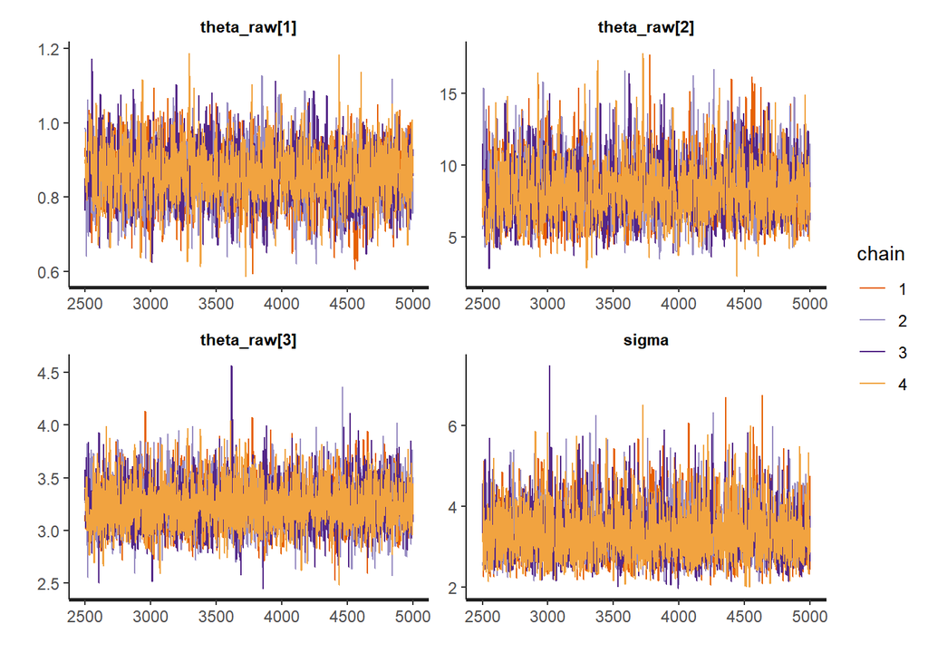

```r
traceplot(stan_sir_w_alpha, pars=c('theta_raw', 'sigma'), labels=c('alpha', 'beta', 'gamma', 'sigma'))
```

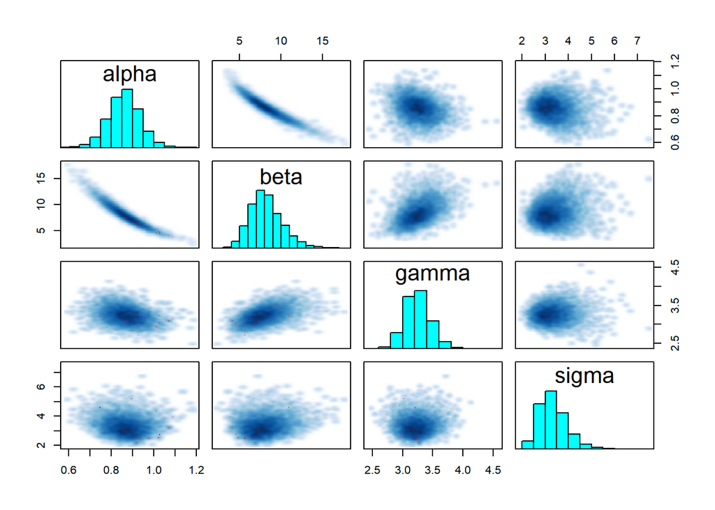

```r
pairs(stan_sir_w_alpha, pars=c('theta_raw', 'sigma'), labels=c('alpha', 'beta', 'gamma', 'sigma'))
```

```r
# Print information for all the parameters
# print(stan_sir_w_alpha)
# print(Eyam)
```

```r
summary(stan_sir_w_alpha, pars=c('theta_raw', 'sigma'))
```

```
## $summary
##                   mean     se_mean         sd      2.5%       25%      50%
## theta_raw[1] 0.8606134 0.001500734 0.07389585 0.7149776 0.8132898 0.860934
## theta_raw[2] 8.2309859 0.041679607 1.97996098 4.9045658 6.8693170 8.021575
## theta_raw[3] 3.2477267 0.003274054 0.20873636 2.8636914 3.1058452 3.238084
## sigma        3.3357423 0.009785655 0.59653120 2.4084801 2.9086834 3.258150
##                    75%     97.5%    n_eff     Rhat
## theta_raw[1] 0.9077031  1.008443 2424.557 1.001120
## theta_raw[2] 9.3641587 12.692461 2256.660 1.000966
## theta_raw[3] 3.3787813  3.689422 4064.662 1.000336
## sigma        3.6753797  4.727645 3716.093 1.000291
##
## $c_summary
## , , chains = chain:1
##
##               stats
## parameter           mean         sd      2.5%       25%       50%       75%
##   theta_raw[1] 0.8562509 0.07398903 0.7032759 0.8070217 0.8591106 0.9049674
##   theta_raw[2] 8.3353275 2.01406486 5.0401279 6.9653861 8.0712712 9.4874005
##   theta_raw[3] 3.2476933 0.20476553 2.8814721 3.1030807 3.2395672 3.3722518
##   sigma        3.3479283 0.59646301 2.4189495 2.9178763 3.2731139 3.6869254
##               stats
## parameter          97.5%
##   theta_raw[1]  1.000455
##   theta_raw[2] 13.117646
##   theta_raw[3]  3.699780
##   sigma         4.743519
##
## , , chains = chain:2
##
##               stats
## parameter           mean         sd      2.5%       25%       50%       75%
##   theta_raw[1] 0.8603975 0.07617925 0.7095789 0.8107667 0.8613494 0.9098308
##   theta_raw[2] 8.2488709 2.06409728 4.8287541 6.7983229 8.0118946 9.4358735
##   theta_raw[3] 3.2464838 0.21790029 2.8542531 3.0974335 3.2324281 3.3812510
##   sigma        3.3386443 0.58501860 2.4365324 2.9104065 3.2743474 3.6652833
##               stats
## parameter          97.5%
##   theta_raw[1]  1.013365
##   theta_raw[2] 13.007984
```

[output cut: 17 more lines]

```
##
## , , chains = chain:4
##
##               stats
## parameter           mean         sd      2.5%       25%      50%       75%
##   theta_raw[1] 0.8634906 0.07118484 0.7253733 0.8179174 0.861938 0.9074281
##   theta_raw[2] 8.1346781 1.89605085 4.8117598 6.8545354 7.969502 9.2170027
##   theta_raw[3] 3.2415356 0.20323480 2.8774616 3.1028073 3.229832 3.3713163
##   sigma        3.3119062 0.59307633 2.4036013 2.9047008 3.221088 3.6352178
##               stats
## parameter          97.5%
##   theta_raw[1]  1.006055
##   theta_raw[2] 12.162404
##   theta_raw[3]  3.652763
##   sigma         4.730357
```

```r
samples = extract(stan_sir_w_alpha)

# Create data frame of ODE solutions adding initial condition at the begining of the data frame
y_hat_summ = summary(stan_sir_w_alpha, pars=c('y_hat'))$summary
mu_summ = summary(stan_sir_w_alpha, pars=c('mu'))$summary

df_y_hat = data.frame(median=as.numeric(c(mu_summ[,"50%"],y_hat_summ[,"50%"])),
                      time = rep(Eyam$time, each=3),
                      Pop = rep(c('S', 'I', 'R'), 8)
                      )
head(df_y_hat)
```

|  | median | time | Pop |
| --- | --- | --- | --- |
| 1 | 255.960119 | 0.0 | S |
| 2 | 3.146575 | 0.0 | I |
| 3 | 1.562914 | 0.0 | R |
| 4 | 236.155598 | 0.5 | S |
| 5 | 11.734991 | 0.5 | I |
| 6 | 13.007063 | 0.5 | R |

```r
# Create posterior checks summary

y_checks_summ = summary(stan_sir_w_alpha, pars=c('y_checks'))$summary

df_pred = data.frame(time=rep(Eyam$time, each=3),
                     ymin = as.numeric(y_checks_summ[,'2.5%']),
                     ymax = as.numeric(y_checks_summ[,'97.5%']),
                     ymedian = as.numeric(y_checks_summ[,'50%']),
                     ymean = as.numeric(y_checks_summ[,'mean']),
                     Pop = rep(c('S', 'I', 'R'), 8)
                    )
head(df_pred)
```

|  | time | ymin | ymax | ymedian | ymean | Pop |
| --- | --- | --- | --- | --- | --- | --- |
| 1 | 0.0 | 248.103255 | 263.429458 | 255.981148 | 255.923680 | S |
| 2 | 0.0 | -4.073756 | 10.205411 | 3.275359 | 3.219266 | I |
| 3 | 0.0 | -5.119669 | 9.191796 | 1.773115 | 1.846864 | R |
| 4 | 0.5 | 228.491732 | 243.712197 | 236.109965 | 236.126191 | S |
| 5 | 0.5 | 4.517195 | 19.168032 | 11.778626 | 11.790972 | I |
| 6 | 0.5 | 5.679239 | 20.588963 | 13.022958 | 13.084619 | R |

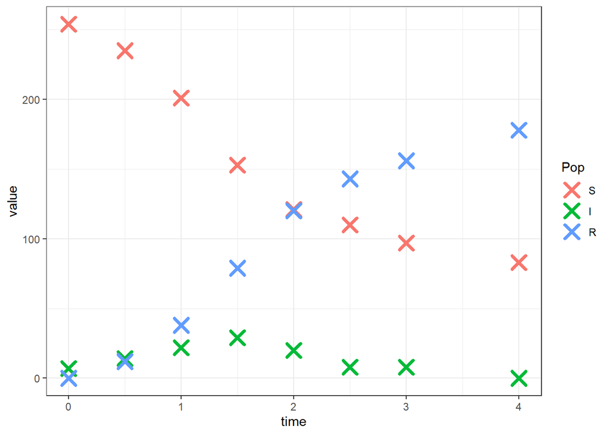

```r
TOT_SAMPLES = dim(samples$y_pred_mean)[1]

# Eyam data

ggplot() +
  geom_point(data=df_Eyam,
           aes(x=time, y=value, group=Pop, colour=Pop), size=4, shape=4, stroke=2) +
  theme_bw() -> sir_plot_base
print(sir_plot_base)
```

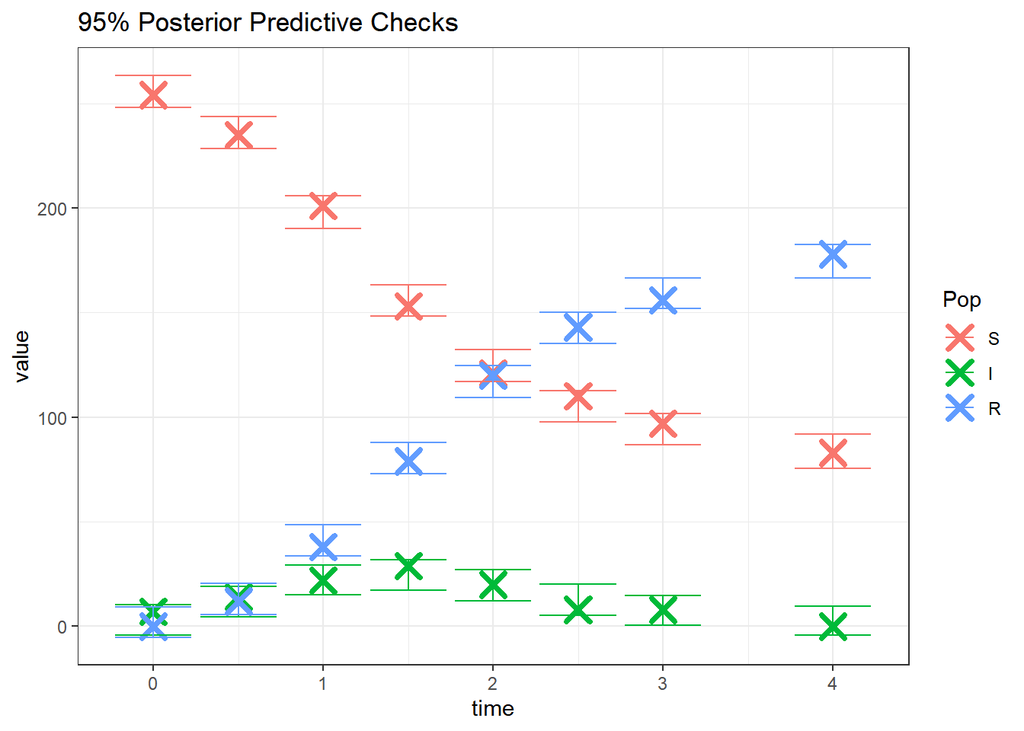

```r
# 95% Bayesian credible error bars for posterior checks

sir_plot = sir_plot_base +
  geom_errorbar(data=df_pred,
                aes(x=time, ymin=ymin, ymax=ymax, group=Pop, colour=Pop)) +
  ggtitle('95% Posterior Predictive Checks')
print(sir_plot)
```

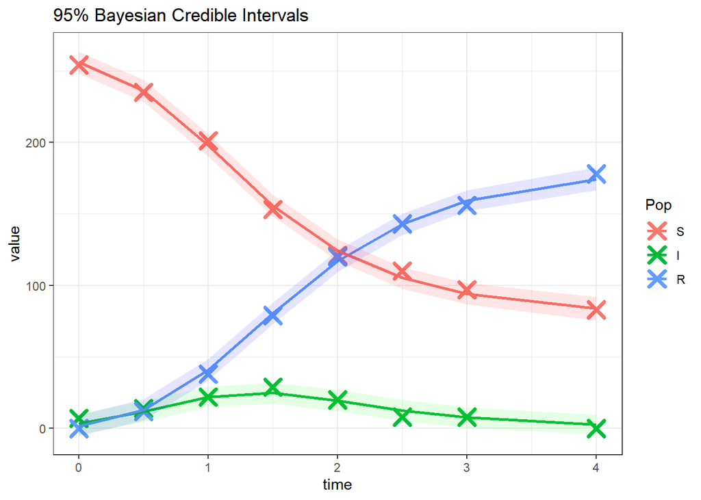

```r
# Fitted line
sir_plot = sir_plot_base +
  geom_line(data = df_pred, aes(x=time, y=ymedian, group=Pop, colour=Pop), size=1,
            alpha=1) +
  geom_ribbon(data=df_pred, aes(x=time, ymin=ymin, ymax=ymax, group=Pop, fill=Pop),
              alpha=0.1,show.legend = FALSE)+
  ggtitle('95% Bayesian Credible Intervals')+
  scale_fill_manual(values=c("green", 'blue', 'red'))
print(sir_plot)
```

## Exercise: Fit the SIR model without the mixing parameter alpha

# Session Info

```r
library(utils)
```